# Garfield County Home Sales 2014 - 2016

Casey Bates

10/27/2018

Read in combined dataset that was cleaned in Python. Shortcut for assignment operator: option + minus. Shortcut for pipe operator: shift + command + M

```r
library(tidyverse)
garfield_county_data <- read_csv("garfield_county_combined.csv")
glimpse(garfield_county_data)
```

```
## Observations: 1,966
## Variables: 13
## $ X1                    <int> 0, 1, 2, 3, 4, 5, 6, 7, 8, 9, 10, 11, 12...
## $ `Inspection Date`     <date> 2014-07-04, 2015-11-06, 2015-03-10, 201...
## $ `Sale Date`           <date> 2014-08-08, 2015-12-11, 2015-04-14, 201...
## $ `Sale Price`          <int> 210000, 265000, 308500, 160000, 340000, ...
## $ Location              <chr> "CARBONDALE", "CARBONDALE", "CARBONDALE"...
## $ Classification        <chr> "Condo", "Condo", "Condo", "Condo", "Con...
## $ `Architectural Style` <chr> "CONDO", "CONDO", "CONDO", "CONDO", "CON...
## $ `Year Built`          <dbl> 1974, 1980, 2008, 1981, 2007, 2007, 2007...
## $ Bedrooms              <dbl> 1, 1, 1, 1, 2, 2, 2, 2, 2, 3, 2, 2, 2, 2...
## $ Baths                 <dbl> 1.00, 1.00, 1.00, 1.00, 1.00, 1.00, 2.00...
## $ `Square Feet`         <dbl> 621, 732, 792, 800, 864, 864, 891, 918, ...
## $ Count                 <int> 1, 1, 1, 1, 1, 1, 1, 1, 1, 1, 1, 1, 1, 1...
## $ `Price per SF`        <dbl> 338.16425, 362.02186, 389.52020, 200.000...
```

Give name to index column:

```r
#I'm not sure why dplyr rename did  not work for this
new_name <- "Index"
garfield_county_data <- garfield_county_data %>% dplyr::rename(!! new_name := X1)
colnames(garfield_county_data)
```

```
##  [1] "Index"               "Inspection Date"     "Sale Date"
##  [4] "Sale Price"          "Location"            "Classification"
##  [7] "Architectural Style" "Year Built"          "Bedrooms"
## [10] "Baths"               "Square Feet"         "Count"
## [13] "Price per SF"
```

Remove spaces from all column names to avoid problems in R:

```r
library(magrittr)
colnames(garfield_county_data) %<>% str_replace_all("\\s", "_")
colnames(garfield_county_data)
```

```
##  [1] "Index"               "Inspection_Date"     "Sale_Date"
##  [4] "Sale_Price"          "Location"            "Classification"
##  [7] "Architectural_Style" "Year_Built"          "Bedrooms"
## [10] "Baths"               "Square_Feet"         "Count"
## [13] "Price_per_SF"
```

#Linear Regression Show linear regression line of Sale Price vs. Square Feet

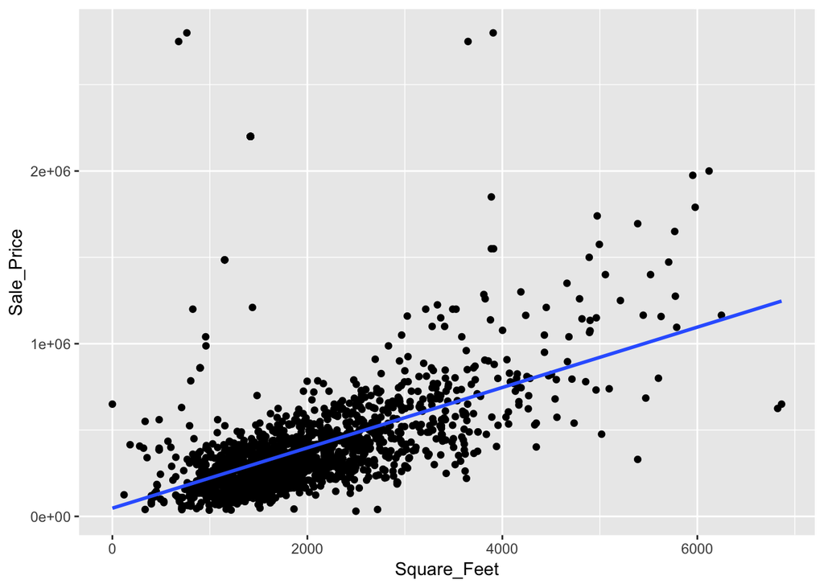

```r
ggplot(data = garfield_county_data, aes(x = Square_Feet, y = Sale_Price)) +
  geom_point() +
  geom_smooth(method = "lm", se = FALSE) #Method set to lm for the linear model
```

Explore high sale price observations:

```r
garfield_county_data %>% arrange(desc(Sale_Price)) %>% select(c("Sale_Price", "Location", "Classification", "Bedrooms", "Square_Feet", "Price_per_SF")) %>% head(30)
```

```
## # A tibble: 30 x 6
##    Sale_Price Location   Classification Bedrooms Square_Feet Price_per_SF
##         <int> <chr>      <chr>             <dbl>       <dbl>        <dbl>
##  1    2800000 CARBONDALE Single Family         2         764        3665.
##  2    2800000 CARBONDALE Single Family         2        3906         717.
##  3    2750000 CARBONDALE Single Family         0         680        4044.
##  4    2750000 CARBONDALE Single Family         3        3648         754.
##  5    2200000 RIFLE      Townhome              3        1417        1553.
##  6    2200000 RIFLE      Townhome              3        1417        1553.
##  7    2200000 RIFLE      Townhome              3        1417        1553.
##  8    2200000 RIFLE      Townhome              3        1417        1553.
##  9    2200000 RIFLE      Townhome              3        1417        1553.
## 10    2200000 RIFLE      Townhome              3        1417        1553.
## # ... with 20 more rows
```

Were there really multiple sales of townhomes in Rifle at $2.2M? Seems suspicious that all sales are identical and on the same date. Will need to read-in the original dataset to find out.

```r
garfield_county_data %>% filter(Sale_Price == 2200000 & Location == "RIFLE")
```

```
## # A tibble: 23 x 13
##    Index Inspection_Date Sale_Date  Sale_Price Location Classification
##    <int> <date>          <date>          <int> <chr>    <chr>
##  1   503 2014-12-26      2015-01-30    2200000 RIFLE    Townhome
##  2   505 2014-12-26      2015-01-30    2200000 RIFLE    Townhome
##  3   507 2014-12-26      2015-01-30    2200000 RIFLE    Townhome
##  4   509 2014-12-26      2015-01-30    2200000 RIFLE    Townhome
##  5   511 2014-12-26      2015-01-30    2200000 RIFLE    Townhome
##  6   512 2014-12-26      2015-01-30    2200000 RIFLE    Townhome
##  7   514 2014-12-26      2015-01-30    2200000 RIFLE    Townhome
##  8   516 2014-12-26      2015-01-30    2200000 RIFLE    Townhome
##  9   518 2014-12-26      2015-01-30    2200000 RIFLE    Townhome
## 10   520 2014-12-26      2015-01-30    2200000 RIFLE    Townhome
## # ... with 13 more rows, and 7 more variables: Architectural_Style <chr>,
## #   Year_Built <dbl>, Bedrooms <dbl>, Baths <dbl>, Square_Feet <dbl>,
## #   Count <int>, Price_per_SF <dbl>
```

Read-in the original townhome/condo sales dataset.

```r
garfield_county_condos <- read_csv("2017-comparable-sales-condos-townhomes.csv")
garfield_county_condos %>% filter(`Sale Price` == "$2,200,000" & Location == "RIFLE")
```

```
## # A tibble: 23 x 14
##    Account `Parcel Number` Reception `Sale Date` `Sale Price`
##    <chr>   <chr>               <int> <chr>       <chr>
##  1 R082978 217704355001       858946 1/30/2015   $2,200,000
##  2 R082979 217704355002       858946 1/30/2015   $2,200,000
##  3 R082981 217704355004       858946 1/30/2015   $2,200,000
##  4 R082982 217704356001       858946 1/30/2015   $2,200,000
##  5 R082983 217704356002       858946 1/30/2015   $2,200,000
##  6 R082985 217704356004       858946 1/30/2015   $2,200,000
##  7 R082986 217704357001       858946 1/30/2015   $2,200,000
##  8 R082987 217704357002       858946 1/30/2015   $2,200,000
##  9 R082988 217704357003       858946 1/30/2015   $2,200,000
## 10 R082989 217704357004       858946 1/30/2015   $2,200,000
## # ... with 13 more rows, and 9 more variables: `Situs Address` <chr>,
## #   Location <chr>, Classification <chr>, `Architectural Style` <chr>,
## #   `Actual Year Built` <int>, Bedrooms <int>, Baths <dbl>, `Heated
## #   Area` <dbl>, Legal <chr>
```

Inspecting the data reveals that each sale has a different site address, indicating that perhaps one party purchased the entire block of townhomes. This data will remain in the dataset. Now to create a linear regression model of sale price as a function of square footage

```r
model <- lm(Sale_Price ~ Square_Feet, data = garfield_county_data)
```

Look at the coefficients of the model:

```r
coef(model)
```

```
## (Intercept) Square_Feet
##  47477.7867    174.7282
```

Create a coefs tibble for use when manually fitting the regression line:

```r
coefs <- tibble(
  `(Intercept)` = 47477.7867,
  Square_Feet = 174.7282)
coefs
```

```
## # A tibble: 1 x 2
##   `(Intercept)` Square_Feet
##           <dbl>       <dbl>
## 1        47478.        175.
```

A better way to do it would be to extract this information from a tidy version of the summary table:

```r
library(broom)
tidy_model <- tidy(model)
tidy_model
```

```
## # A tibble: 2 x 5
##   term        estimate std.error statistic   p.value
##   <chr>          <dbl>     <dbl>     <dbl>     <dbl>
## 1 (Intercept)   47478.  15094.        3.15 1.68e-  3
## 2 Square_Feet     175.      7.19     24.3  2.21e-114
```

Look at the full output of the model:

```r
summary(model)
```

```
##
## Call:
## lm(formula = Sale_Price ~ Square_Feet, data = garfield_county_data)
##
## Residuals:
##     Min      1Q  Median      3Q     Max
## -658966 -124490  -52861   47415 2619030
##
## Coefficients:
##              Estimate Std. Error t value Pr(>|t|)
## (Intercept) 47477.787  15093.893   3.145  0.00168 **
## Square_Feet   174.728      7.186  24.315  < 2e-16 ***
## ---
## Signif. codes:  0 '***' 0.001 '**' 0.01 '*' 0.05 '.' 0.1 ' ' 1
##
## Residual standard error: 287400 on 1964 degrees of freedom
## Multiple R-squared:  0.2314, Adjusted R-squared:  0.231
## F-statistic: 591.2 on 1 and 1964 DF,  p-value: < 2.2e-16
```

From DataCamp: One way to assess strength of fit is to consider how far off the model is for a typical case. That is, for some observations, the fitted value will be very close to the actual value, while for others it will not. The magnitude of a typical residual can give us a sense of generally how close our estimates are.

The adjusted r-squared value of only 0.231 indicates that square footage alone does not explain sale price. This value is the proportion of the variance explained by our model (, so only about 23%).

From DataCamp: The least squares fitting procedure guarantees that the mean of the residuals is zero (n.b., numerical instability may result in the computed values not being exactly zero). At the same time, the mean of the fitted values must equal the mean of the response variable.

In this exercise, we will confirm these two mathematical facts by accessing the fitted values and residuals with the fitted.values() and residuals() functions, respectively, for the following model:

```r
mean(garfield_county_data$Sale_Price) == mean(fitted.values(model))
```

```
## [1] TRUE
```

This value should be near zero:

```r
mean(residuals(model))
```

```
## [1] 1.05004e-11
```

From DataCamp: However, recall that some of the residuals are positive, while others are negative. In fact, it is guaranteed by the least squares fitting procedure that the mean of the residuals is zero. Thus, it makes more sense to compute the square root of the mean squared residual, or root mean squared error (RMSE). R calls this quantity the residual standard error.

To make this estimate unbiased, you have to divide the sum of the squared residuals by the degrees of freedom in the model.

You can recover the residuals from mod with `residuals()`, and the degrees of freedom with `df.residual()`.

```r
# Compute RMSE
sqrt(sum(residuals(model)^2) / df.residual(model))
```

```
## [1] 287364.3
```

SSE null model, with the constant 1 inserted as the explanatory variable (line is flat on y-hat intercept, the mean value of y).

```r
model_null <- lm(Sale_Price ~ 1, data = garfield_county_data)
SST <- model_null %>%
  augment(garfield_county_data) %>%
  summarize(SST = sum(.resid^2))
SST
```

```
## # A tibble: 1 x 1
##       SST
##     <dbl>
## 1 2.11e14
```

Calculate SSE:

```r
SSE <- model %>%
  augment() %>%
  summarize(SSE = sum(.resid^2))
SSE
```

```
## # A tibble: 1 x 1
##       SSE
##     <dbl>
## 1 1.62e14
```

The ratio of the SSE for our model, to the SSE for the null model is a quantification of the variability explained by our model. SST = Total sum of the squares. A measure of variability in the response variable. The portion that is not explained by our model is the SSE. So this is r-squared, which is the proportion of the variability in the response variable that is explained by our model. Most commonly cited measure of the quality of fit of the regression model.

Calculate r-squared as 1 minus SSE/SST

```r
1 - 1.621836e+14/2.110045e+14
```

```
## [1] 0.2313737
```

Or using the object names:

```r
1 - SSE/SST
```

```
##         SSE
## 1 0.2313734
```

The above calculation matches the r-squared value from the model.

Add a regression line manually (for the sake of practice):

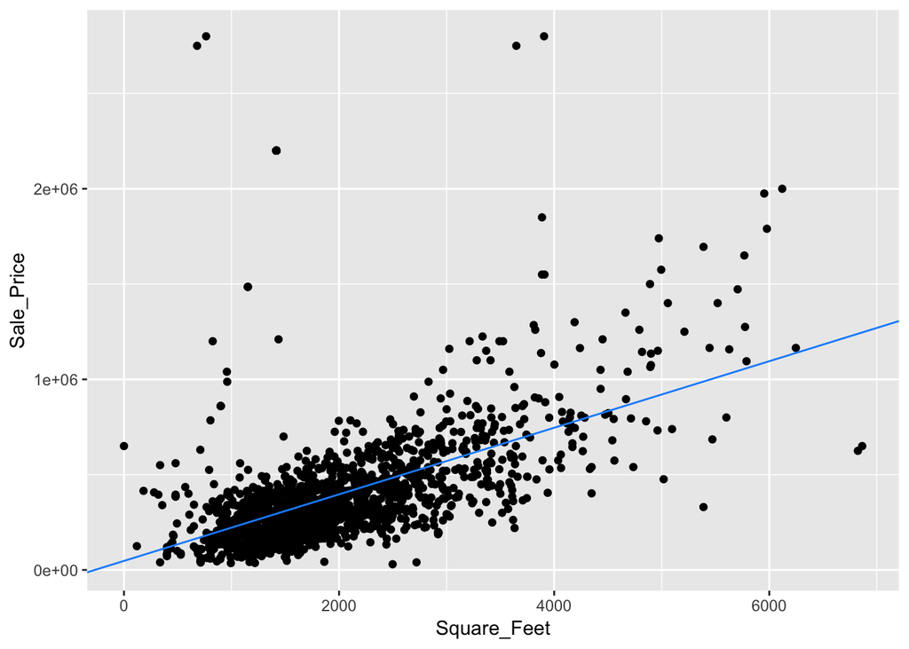

```r
ggplot(data = garfield_county_data, aes(x = Square_Feet, y = Sale_Price)) +
  geom_point() +
  geom_abline(data = coefs,
              aes(intercept = `(Intercept)`, slope = Square_Feet),
              color = "dodgerblue")
```

Create a new data frame called garfield_county_tidy that is the augmentation of the model linear model. The garfield_data_tidy data frame is the result of augment()-ing the garfield_county_data data frame with the model for Sale_Price as a function of Square_Feet.

```r
library(broom)
garfield_data_tidy <- augment(model)
glimpse(garfield_data_tidy)
```

```
## Observations: 1,966
## Variables: 9
## $ Sale_Price  <int> 210000, 265000, 308500, 160000, 340000, 45000, 251...
## $ Square_Feet <dbl> 621, 732, 792, 800, 864, 864, 891, 918, 946, 946, ...
## $ .fitted     <dbl> 155984.0, 175378.8, 185862.5, 187260.4, 198443.0, ...
## $ .se.fit     <dbl> 11228.338, 10586.984, 10249.448, 10204.976, 9854.0...
## $ .resid      <dbl> 54015.98, 89621.15, 122637.46, -27260.37, 141557.0...
## $ .hat        <dbl> 0.0015267412, 0.0013573098, 0.0012721413, 0.001261...
## $ .sigma      <dbl> 287434.9, 287430.3, 287424.1, 287436.8, 287419.7, ...
## $ .cooksd     <dbl> 2.705463e-05, 6.618875e-05, 1.161427e-04, 5.688822...
## $ .std.resid  <dbl> 0.18811407, 0.31208484, 0.42703824, -0.09492333, 0...
```

DataCamp instructions: Use the garfield_data_tidy data frame to compute the R2 of model manually using the formula above, by computing the ratio of the variance of the residuals to the variance of the response variable.

```r
# Compute R-squared
garfield_data_tidy %>%
  summarize(var_y = var(Sale_Price), var_e = var(.resid)) %>%
  mutate(R_squared = 1 - var_e/var_y)
```

```
## # A tibble: 1 x 3
##           var_y        var_e R_squared
##           <dbl>        <dbl>     <dbl>
## 1 107381403195. 82536204381.     0.231
```

So, 23 percent of the variability in Sale Price can be explained by Square Footage.

Now looking to see how r-squared changes when adding a second variable, in this case it’s location.

```r
model2 <- lm(Sale_Price ~ Square_Feet + Location, data = garfield_county_data)
summary(model2)
```

```
##
## Call:
## lm(formula = Sale_Price ~ Square_Feet + Location, data = garfield_county_data)
##
## Residuals:
##     Min      1Q  Median      3Q     Max
## -761895  -97035  -34056   27456 2383333
##
## Coefficients:
##                      Estimate Std. Error t value Pr(>|t|)
## (Intercept)         3.051e+05  2.122e+04   14.38   <2e-16 ***
## Square_Feet         1.460e+02  6.895e+00   21.18   <2e-16 ***
## LocationGLENWOOD   -1.923e+05  1.895e+04  -10.15   <2e-16 ***
## LocationNEW CASTLE -2.626e+05  2.047e+04  -12.83   <2e-16 ***
## LocationPARACHUTE  -3.712e+05  2.364e+04  -15.70   <2e-16 ***
## LocationRIFLE      -2.250e+05  1.973e+04  -11.40   <2e-16 ***
## LocationSILT       -2.903e+05  2.272e+04  -12.78   <2e-16 ***
## ---
## Signif. codes:  0 '***' 0.001 '**' 0.01 '*' 0.05 '.' 0.1 ' ' 1
##
## Residual standard error: 266500 on 1959 degrees of freedom
## Multiple R-squared:  0.3408, Adjusted R-squared:  0.3388
## F-statistic: 168.8 on 6 and 1959 DF,  p-value: < 2.2e-16
```

Unfortunately the dataset does not include any information about lot size/acreage. Next step is to look at how the model responds to removing property sales that included no bedrooms, no bathrooms, or no square footage. Any of these variables with a value of zero likely indicate that it was primarily a land sale, which we are not interested in for the purpose of home inspections. For reference, the original dataset had 1,966 observations.

```r
no_zeros <- garfield_county_data %>% filter(Bedrooms > 0 & Baths > 0 & Square_Feet > 0)
glimpse(no_zeros)
```

```
## Observations: 1,959
## Variables: 13
## $ Index               <int> 0, 1, 2, 3, 4, 5, 6, 7, 8, 9, 10, 11, 12, ...
## $ Inspection_Date     <date> 2014-07-04, 2015-11-06, 2015-03-10, 2015-...
## $ Sale_Date           <date> 2014-08-08, 2015-12-11, 2015-04-14, 2016-...
## $ Sale_Price          <int> 210000, 265000, 308500, 160000, 340000, 45...
## $ Location            <chr> "CARBONDALE", "CARBONDALE", "CARBONDALE", ...
## $ Classification      <chr> "Condo", "Condo", "Condo", "Condo", "Condo...
## $ Architectural_Style <chr> "CONDO", "CONDO", "CONDO", "CONDO", "CONDO...
## $ Year_Built          <dbl> 1974, 1980, 2008, 1981, 2007, 2007, 2007, ...
## $ Bedrooms            <dbl> 1, 1, 1, 1, 2, 2, 2, 2, 2, 3, 2, 2, 2, 2, ...
## $ Baths               <dbl> 1.00, 1.00, 1.00, 1.00, 1.00, 1.00, 2.00, ...
## $ Square_Feet         <dbl> 621, 732, 792, 800, 864, 864, 891, 918, 94...
## $ Count               <int> 1, 1, 1, 1, 1, 1, 1, 1, 1, 1, 1, 1, 1, 1, ...
## $ Price_per_SF        <dbl> 338.16425, 362.02186, 389.52020, 200.00000...
```

The filter above only removed 7 observations. Probably not enough to make a significant difference.

```r
model3 <- lm(Sale_Price ~ Square_Feet, data = no_zeros)
summary(model3)
```

```
##
## Call:
## lm(formula = Sale_Price ~ Square_Feet, data = no_zeros)
##
## Residuals:
##     Min      1Q  Median      3Q     Max
## -670265 -121792  -50008   48117 2625720
##
## Coefficients:
##             Estimate Std. Error t value Pr(>|t|)
## (Intercept) 37816.10   14874.45   2.542   0.0111 *
## Square_Feet   178.62       7.07  25.265   <2e-16 ***
## ---
## Signif. codes:  0 '***' 0.001 '**' 0.01 '*' 0.05 '.' 0.1 ' ' 1
##
## Residual standard error: 281200 on 1957 degrees of freedom
## Multiple R-squared:  0.246,  Adjusted R-squared:  0.2456
## F-statistic: 638.3 on 1 and 1957 DF,  p-value: < 2.2e-16
```

#Linear regression of Square_Feet vs. Sale_Price for each of the six locations First thing we need to do is split up the dataframe into one dataset for each location. We will do this with the no_zeros dataframe. We will nest by location where we end up with a dataframe with one row for each Location where each row in the `data` column is a dataframe of all other columns besides country. This is a list column containing dataframes.

```r
# Step 1: Nest by location
library(tidyr)
no_zeros_nested <- no_zeros %>%
  nest(-Location)
no_zeros_nested
```

```
## # A tibble: 6 x 2
##   Location   data
##   <chr>      <list>
## 1 CARBONDALE <tibble [376 × 12]>
## 2 GLENWOOD   <tibble [440 × 12]>
## 3 NEW CASTLE <tibble [326 × 12]>
## 4 PARACHUTE  <tibble [201 × 12]>
## 5 RIFLE      <tibble [393 × 12]>
## 6 SILT       <tibble [223 × 12]>
```

Check this by printing the data nested for New Castle

```r
no_zeros_nested$data[[3]]
```

```
## # A tibble: 326 x 12
##    Index Inspection_Date Sale_Date  Sale_Price Classification
##    <int> <date>          <date>          <int> <chr>
##  1   316 2015-01-20      2015-02-24     115500 Condo
##  2   317 2015-06-26      2015-07-31     115000 Condo
##  3   318 2016-05-11      2016-06-15     139500 Condo
##  4   319 2014-06-25      2014-07-30     122000 Condo
##  5   320 2015-07-28      2015-09-01     115000 Condo
##  6   321 2015-06-12      2015-07-17      60000 Condo
##  7   322 2015-10-19      2015-11-23     150000 Condo
##  8   323 2015-09-23      2015-10-28     130000 Townhome
##  9   324 2015-07-10      2015-08-14     129000 Townhome
## 10   325 2014-08-11      2014-09-15     119000 Townhome
## # ... with 316 more rows, and 7 more variables: Architectural_Style <chr>,
## #   Year_Built <dbl>, Bedrooms <dbl>, Baths <dbl>, Square_Feet <dbl>,
## #   Count <int>, Price_per_SF <dbl>
```

If we want to unnest the nested we can do it like this:

```r
unnest(no_zeros_nested)
```

```
## # A tibble: 1,959 x 13
##    Location Index Inspection_Date Sale_Date  Sale_Price Classification
##    <chr>    <int> <date>          <date>          <int> <chr>
##  1 CARBOND…     0 2014-07-04      2014-08-08     210000 Condo
##  2 CARBOND…     1 2015-11-06      2015-12-11     265000 Condo
##  3 CARBOND…     2 2015-03-10      2015-04-14     308500 Condo
##  4 CARBOND…     3 2015-12-16      2016-01-20     160000 Condo
##  5 CARBOND…     4 2016-03-04      2016-04-08     340000 Condo
##  6 CARBOND…     5 2014-05-27      2014-07-01      45000 Condo
##  7 CARBOND…     6 2015-07-24      2015-08-28     251200 Condo
##  8 CARBOND…     7 2016-05-03      2016-06-07     275500 Condo
##  9 CARBOND…     8 2015-04-27      2015-06-01     323000 Condo
## 10 CARBOND…     9 2015-11-12      2015-12-17     323000 Condo
## # ... with 1,949 more rows, and 7 more variables:
## #   Architectural_Style <chr>, Year_Built <dbl>, Bedrooms <dbl>,
## #   Baths <dbl>, Square_Feet <dbl>, Count <int>, Price_per_SF <dbl>
```

Next, use `purrr()` to fit a linear model for each item in a list column. In particular, the `map()` function. `map()` applies an operation to each item in a list. `mutate()` will be used to define the new column “models”. The `map()` function will use information from the “data” column created by the `nest()` function to apply a linear regression to each item of “data”.

```r
# Step 2: Use `map()` to fit a linear model to each dataset
library(purrr)
no_zeros_models <- no_zeros %>%
  nest(-Location) %>%
  mutate(models = map(data, ~lm(Sale_Price ~ Square_Feet, .))) #data has been passed in to lm through map, so dot "." is used for data in the lm call
head(no_zeros_models)
```

```
## # A tibble: 6 x 3
##   Location   data                models
##   <chr>      <list>              <list>
## 1 CARBONDALE <tibble [376 × 12]> <S3: lm>
## 2 GLENWOOD   <tibble [440 × 12]> <S3: lm>
## 3 NEW CASTLE <tibble [326 × 12]> <S3: lm>
## 4 PARACHUTE  <tibble [201 × 12]> <S3: lm>
## 5 RIFLE      <tibble [393 × 12]> <S3: lm>
## 6 SILT       <tibble [223 × 12]> <S3: lm>
```

Next, the broom package will be used to map each item to a tidy dataframe of coefficients. `tidy()` turns each model into a dataframe.

```r
# Step 3: use `map()` to tidy each model
no_zeros_models <- no_zeros %>%
  nest(-Location) %>%
  mutate(models = map(data, ~lm(Sale_Price ~ Square_Feet, .))) %>%
  mutate(tidied = map(models, tidy))
head(no_zeros_models)
```

```
## # A tibble: 6 x 4
##   Location   data                models   tidied
##   <chr>      <list>              <list>   <list>
## 1 CARBONDALE <tibble [376 × 12]> <S3: lm> <tibble [2 × 5]>
## 2 GLENWOOD   <tibble [440 × 12]> <S3: lm> <tibble [2 × 5]>
## 3 NEW CASTLE <tibble [326 × 12]> <S3: lm> <tibble [2 × 5]>
## 4 PARACHUTE  <tibble [201 × 12]> <S3: lm> <tibble [2 × 5]>
## 5 RIFLE      <tibble [393 × 12]> <S3: lm> <tibble [2 × 5]>
## 6 SILT       <tibble [223 × 12]> <S3: lm> <tibble [2 × 5]>
```

Now there are three list columns. So now for each location we have three columns: one with the original data, one with the linear models, and one with a dataframe of tidied coefficients. Tidied versions of statistical models are easy to combine. So now we can use `unnest()` to bring them all into the top level by unnesting the tidied column. Now we have a tidy model for each location.

```r
# Step 4: Unnest to a tidy table of coefficients
location_coefficients <- no_zeros %>%
  nest(-Location) %>%
  mutate(models = map(data, ~lm(Sale_Price ~ Square_Feet, .))) %>%
  mutate(tidied = map(models, tidy)) %>%
  unnest(tidied)
head(location_coefficients)
```

```
## # A tibble: 6 x 6
##   Location   term        estimate std.error statistic  p.value
##   <chr>      <chr>          <dbl>     <dbl>     <dbl>    <dbl>
## 1 CARBONDALE (Intercept)  133708.  31620.        4.23 2.96e- 5
## 2 CARBONDALE Square_Feet     216.     11.9      18.1  4.04e-53
## 3 GLENWOOD   (Intercept)  128779.  11467.       11.2  6.85e-26
## 4 GLENWOOD   Square_Feet     138.      5.39     25.5  1.06e-88
## 5 NEW CASTLE (Intercept)   67058.  10848.        6.18 1.91e- 9
## 6 NEW CASTLE Square_Feet     132.      5.58     23.6  1.55e-72
```

To recap, this was 4 steps: 1. Nest by location 2. Map to fit a model to each data set 3. Map to tidy each model 4. Unnest to a table of coefficients

Now, since the data is tidy, we can manipulate it with dplyr functions. For this exercise, we are interested in how square footage predicts sale price (the slope), not where sale price started (the intercept). So we will filter for term == Square_Feet.

```r
location_slopes <-  location_coefficients %>%
  filter(term == "Square_Feet")
location_slopes
```

```
## # A tibble: 6 x 6
##   Location   term        estimate std.error statistic  p.value
##   <chr>      <chr>          <dbl>     <dbl>     <dbl>    <dbl>
## 1 CARBONDALE Square_Feet   216.       11.9    18.1    4.04e-53
## 2 GLENWOOD   Square_Feet   138.        5.39   25.5    1.06e-88
## 3 NEW CASTLE Square_Feet   132.        5.58   23.6    1.55e-72
## 4 PARACHUTE  Square_Feet   108.        7.57   14.3    1.91e-32
## 5 RIFLE      Square_Feet    -1.81     41.7    -0.0433 9.65e- 1
## 6 SILT       Square_Feet   108.        7.67   14.0    2.03e-32
```

But we will want the intercept to practice manually drawing the regression lines.

```r
location_intercept <-  location_coefficients %>%
  filter(term == ("(Intercept)"))
location_intercept
```

```
## # A tibble: 6 x 6
##   Location   term        estimate std.error statistic  p.value
##   <chr>      <chr>          <dbl>     <dbl>     <dbl>    <dbl>
## 1 CARBONDALE (Intercept)  133708.    31620.     4.23  2.96e- 5
## 2 GLENWOOD   (Intercept)  128779.    11467.    11.2   6.85e-26
## 3 NEW CASTLE (Intercept)   67058.    10848.     6.18  1.91e- 9
## 4 PARACHUTE  (Intercept)   -3531.    13649.    -0.259 7.96e- 1
## 5 RIFLE      (Intercept)  329798.    74387.     4.43  1.21e- 5
## 6 SILT       (Intercept)   82505.    15286.     5.40  1.74e- 7
```

From DataCamp: not all of these slopes can be trusted. Some can be due to random noise. We may want to only get the models that are statistically significant, which would mean that Rifle would be excluded. The p-value for the model is a common metric for whether it was due to noise. A p-value of less than 0.05 is generally the threshold for calling a trend significant.

A common issue with p-values is that when we run many statistical tests and evaluate their p-values we need to do a multiple hypothesis correction. The basic issue is that if you try many tests, some might be less than 0.05 by chance, meaning we need to be more restrictive. R provides a function called `p.adjust()` to make this correction. Rather than filter anything out at this point, I will create a new column of p.adjusted values. Also, the dataset will be arranged by estimate.

```r
location_slopes <-  location_coefficients %>%
  filter(term == "Square_Feet") %>%
  mutate(p.adjusted = p.adjust(p.value)) %>%
  arrange(estimate)
location_slopes
```

```
## # A tibble: 6 x 7
##   Location   term        estimate std.error statistic  p.value p.adjusted
##   <chr>      <chr>          <dbl>     <dbl>     <dbl>    <dbl>      <dbl>
## 1 RIFLE      Square_Feet    -1.81     41.7    -0.0433 9.65e- 1   9.65e- 1
## 2 SILT       Square_Feet   108.        7.67   14.0    2.03e-32   5.73e-32
## 3 PARACHUTE  Square_Feet   108.        7.57   14.3    1.91e-32   5.73e-32
## 4 NEW CASTLE Square_Feet   132.        5.58   23.6    1.55e-72   7.76e-72
## 5 GLENWOOD   Square_Feet   138.        5.39   25.5    1.06e-88   6.35e-88
## 6 CARBONDALE Square_Feet   216.       11.9    18.1    4.04e-53   1.62e-52
```

Based on the results, it looks like the next step will be to investigate what is going on with the Rifle dataset.

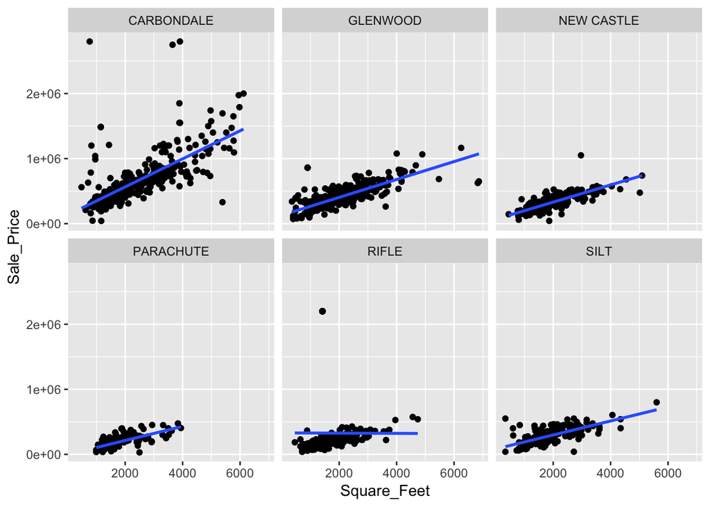

```r
ggplot(data = no_zeros, aes(x = Square_Feet, y = Sale_Price)) +
  geom_point() +
  geom_smooth(method = "lm", se = FALSE) +
  facet_wrap(~ Location)
```

#Many models with purrr and broom R4DS approach to this dataset (Chapter 20) The models capture how square feet influences sale price, and the residuals show what’s left.

```r
library(modelr)
```

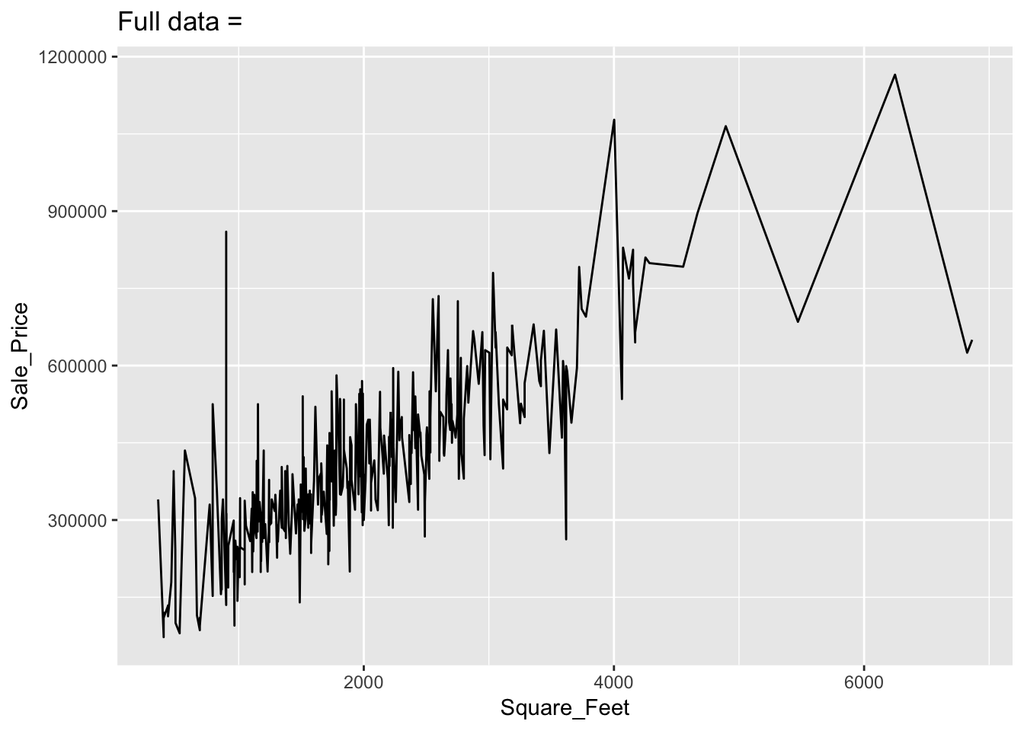

```r
glenwood <- filter(no_zeros, Location == "GLENWOOD")
glenwood %>%
  ggplot(aes(Square_Feet, Sale_Price)) +
  geom_line() +
  ggtitle("Full data = ")
```

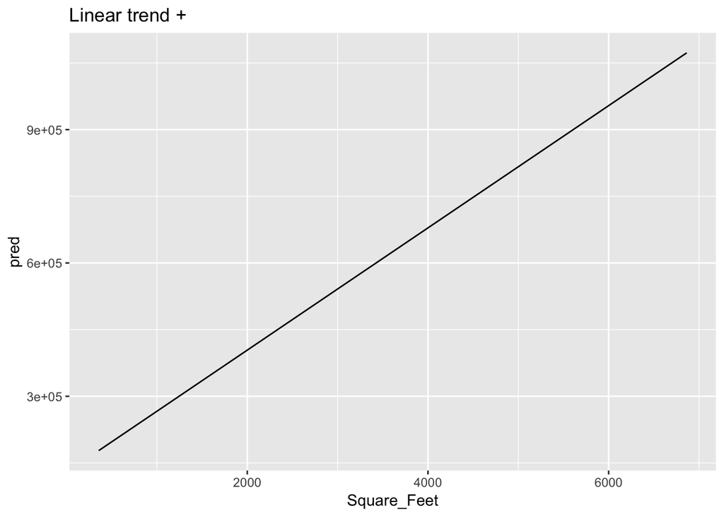

```r
glenwood_mod <- lm(Sale_Price ~ Square_Feet, data = glenwood)
glenwood %>%
  add_predictions(glenwood_mod) %>%
  ggplot(aes(Square_Feet, pred)) +
  geom_line() +
  ggtitle("Linear trend + ")
```

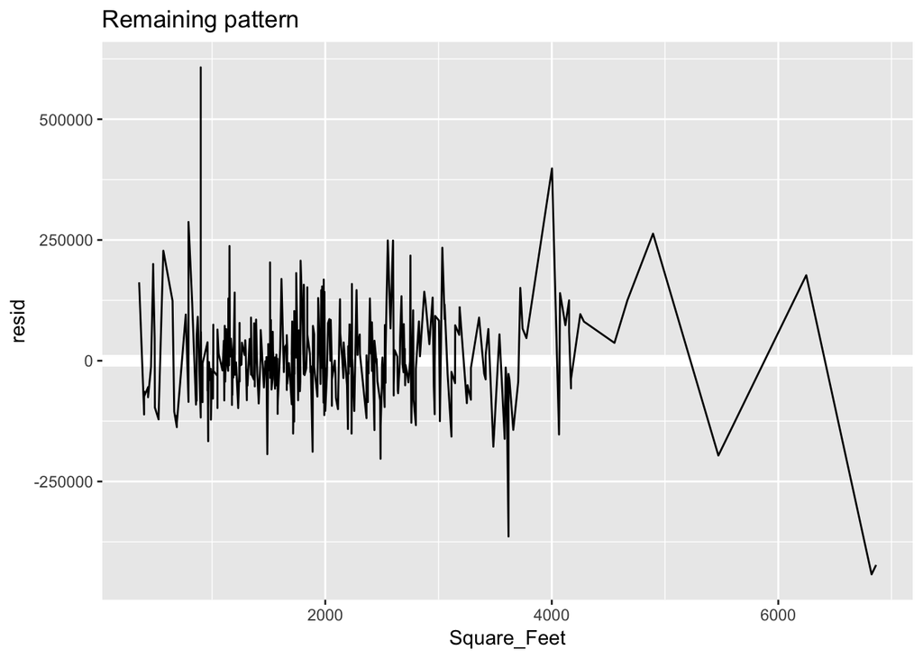

```r
glenwood %>%
  add_residuals(glenwood_mod) %>%
  ggplot(aes(Square_Feet, resid)) +
  geom_hline(yintercept = 0, color = "white", size = 3) +
  geom_line() +
  ggtitle("Remaining pattern")
```

To repeat the above for all six locations, we will need to create a nested dataframe to repeat this action for each location using purrr. We’ve seen how to do this above, but now we will try the approach outlined by Hadley Wickam.

```r
by_location <- no_zeros %>%
  group_by(Location) %>%
  nest()
by_location
```

```
## # A tibble: 6 x 2
##   Location   data
##   <chr>      <list>
## 1 CARBONDALE <tibble [376 × 12]>
## 2 GLENWOOD   <tibble [440 × 12]>
## 3 NEW CASTLE <tibble [326 × 12]>
## 4 PARACHUTE  <tibble [201 × 12]>
## 5 RIFLE      <tibble [393 × 12]>
## 6 SILT       <tibble [223 × 12]>
```

```r
# Equivalent method outlined by David Robinson used above would be:
#by_location <- no_zeros %>%
  #nest(-Location)
```

According to Wickam, there is no great way to explore the nested dataframes. So the best thing we can do is inspect one of them:

```r
by_location$data[[4]] #Parachute
```

```
## # A tibble: 201 x 12
##    Index Inspection_Date Sale_Date  Sale_Price Classification
##    <int> <date>          <date>          <int> <chr>
##  1   429 2014-09-12      2014-10-17      65500 Townhome
##  2   430 2016-05-26      2016-06-30     110000 Townhome
##  3   431 2016-01-28      2016-03-03     106000 Townhome
##  4   432 2015-09-21      2015-10-26      67000 Townhome
##  5   433 2015-06-01      2015-07-06     140000 Townhome
##  6   434 2015-02-18      2015-03-25      89270 Townhome
##  7   435 2015-10-27      2015-12-01     110000 Townhome
##  8   436 2015-09-18      2015-10-23     122000 Townhome
##  9   437 2015-05-27      2015-07-01     243842 Townhome
## 10   438 2015-04-29      2015-06-03     147000 Townhome
## # ... with 191 more rows, and 7 more variables: Architectural_Style <chr>,
## #   Year_Built <dbl>, Bedrooms <dbl>, Baths <dbl>, Square_Feet <dbl>,
## #   Count <int>, Price_per_SF <dbl>
```

Now that we have our nested dataframe we’re in a good position to fit some models. Here is the model fitting function:

```r
location_model <- function(df){
  lm(Sale_Price ~ Square_Feet, data = df)
}
```

And we want to apply it to every data frame. The dataframes are in a list, so we can use purrrr::map() to apply location_model to each element:

```r
# models <- map(by_location$data, location_model)
```

However, rather than leaving the list of models as a free-floating element (as stated by Wickam) it’s better to store this information as a column in the by_location dataframe.

```r
by_location <- by_location %>%
  mutate(model = map(data, location_model))
by_location
```

```
## # A tibble: 6 x 3
##   Location   data                model
##   <chr>      <list>              <list>
## 1 CARBONDALE <tibble [376 × 12]> <S3: lm>
## 2 GLENWOOD   <tibble [440 × 12]> <S3: lm>
## 3 NEW CASTLE <tibble [326 × 12]> <S3: lm>
## 4 PARACHUTE  <tibble [201 × 12]> <S3: lm>
## 5 RIFLE      <tibble [393 × 12]> <S3: lm>
## 6 SILT       <tibble [223 × 12]> <S3: lm>
```

The above is a similar approach to that taught by David Robinson except that Wickam abstracted away the linear modeling by creating the location_model function first.

Wickam: This has a big advantage: because all the related objects are stored together, you don’t need to manually keep them in sync when you filter or arrange. The semantics of the dataframe take care of that for you:

```r
by_location %>%
  filter(Location == "SILT")
```

```
## # A tibble: 1 x 3
##   Location data                model
##   <chr>    <list>              <list>
## 1 SILT     <tibble [223 × 12]> <S3: lm>
```

Or arrange:

```r
by_location %>%
  arrange(Location)
```

```
## # A tibble: 6 x 3
##   Location   data                model
##   <chr>      <list>              <list>
## 1 CARBONDALE <tibble [376 × 12]> <S3: lm>
## 2 GLENWOOD   <tibble [440 × 12]> <S3: lm>
## 3 NEW CASTLE <tibble [326 × 12]> <S3: lm>
## 4 PARACHUTE  <tibble [201 × 12]> <S3: lm>
## 5 RIFLE      <tibble [393 × 12]> <S3: lm>
## 6 SILT       <tibble [223 × 12]> <S3: lm>
```

Keeping everything in one place keeps you from reordering or subsetting objects in different ways!

To compute the residuals for all dataframes we will call add_residuals() with each model-data pair:

```r
by_location <- by_location %>%
  mutate(
    resids = map2(data, model, add_residuals)
  )
by_location
```

```
## # A tibble: 6 x 4
##   Location   data                model    resids
##   <chr>      <list>              <list>   <list>
## 1 CARBONDALE <tibble [376 × 12]> <S3: lm> <tibble [376 × 13]>
## 2 GLENWOOD   <tibble [440 × 12]> <S3: lm> <tibble [440 × 13]>
## 3 NEW CASTLE <tibble [326 × 12]> <S3: lm> <tibble [326 × 13]>
## 4 PARACHUTE  <tibble [201 × 12]> <S3: lm> <tibble [201 × 13]>
## 5 RIFLE      <tibble [393 × 12]> <S3: lm> <tibble [393 × 13]>
## 6 SILT       <tibble [223 × 12]> <S3: lm> <tibble [223 × 13]>
```

Now to inspect one of the resids dataframes:

```r
head(by_location$resids[[2]])
```

```
## # A tibble: 6 x 13
##   Index Inspection_Date Sale_Date  Sale_Price Classification
##   <int> <date>          <date>          <int> <chr>
## 1   137 2015-07-24      2015-08-28      75000 Condo
## 2   138 2015-05-18      2015-06-22      84900 Condo
## 3   139 2015-05-08      2015-06-12      80000 Condo
## 4   140 2015-09-10      2015-10-15      72500 Condo
## 5   141 2015-08-13      2015-09-17     120000 Condo
## 6   142 2016-02-25      2016-03-31      82500 Condo
## # ... with 8 more variables: Architectural_Style <chr>, Year_Built <dbl>,
## #   Bedrooms <dbl>, Baths <dbl>, Square_Feet <dbl>, Count <int>,
## #   Price_per_SF <dbl>, resid <dbl>
```

How can you plot a list of dataframes? If we want to plot the residuals we will need to unnest this list of dataframes, like so:

```r
resids <- unnest(by_location, resids)
resids
```

```
## # A tibble: 1,959 x 14
##    Location Index Inspection_Date Sale_Date  Sale_Price Classification
##    <chr>    <int> <date>          <date>          <int> <chr>
##  1 CARBOND…     0 2014-07-04      2014-08-08     210000 Condo
##  2 CARBOND…     1 2015-11-06      2015-12-11     265000 Condo
##  3 CARBOND…     2 2015-03-10      2015-04-14     308500 Condo
##  4 CARBOND…     3 2015-12-16      2016-01-20     160000 Condo
##  5 CARBOND…     4 2016-03-04      2016-04-08     340000 Condo
##  6 CARBOND…     5 2014-05-27      2014-07-01      45000 Condo
##  7 CARBOND…     6 2015-07-24      2015-08-28     251200 Condo
##  8 CARBOND…     7 2016-05-03      2016-06-07     275500 Condo
##  9 CARBOND…     8 2015-04-27      2015-06-01     323000 Condo
## 10 CARBOND…     9 2015-11-12      2015-12-17     323000 Condo
## # ... with 1,949 more rows, and 8 more variables:
## #   Architectural_Style <chr>, Year_Built <dbl>, Bedrooms <dbl>,
## #   Baths <dbl>, Square_Feet <dbl>, Count <int>, Price_per_SF <dbl>,
## #   resid <dbl>
```

Wickam: Each regular column is repeated once for each row in the nested column. Now that we have a regular dataframe we can plot the residuals:

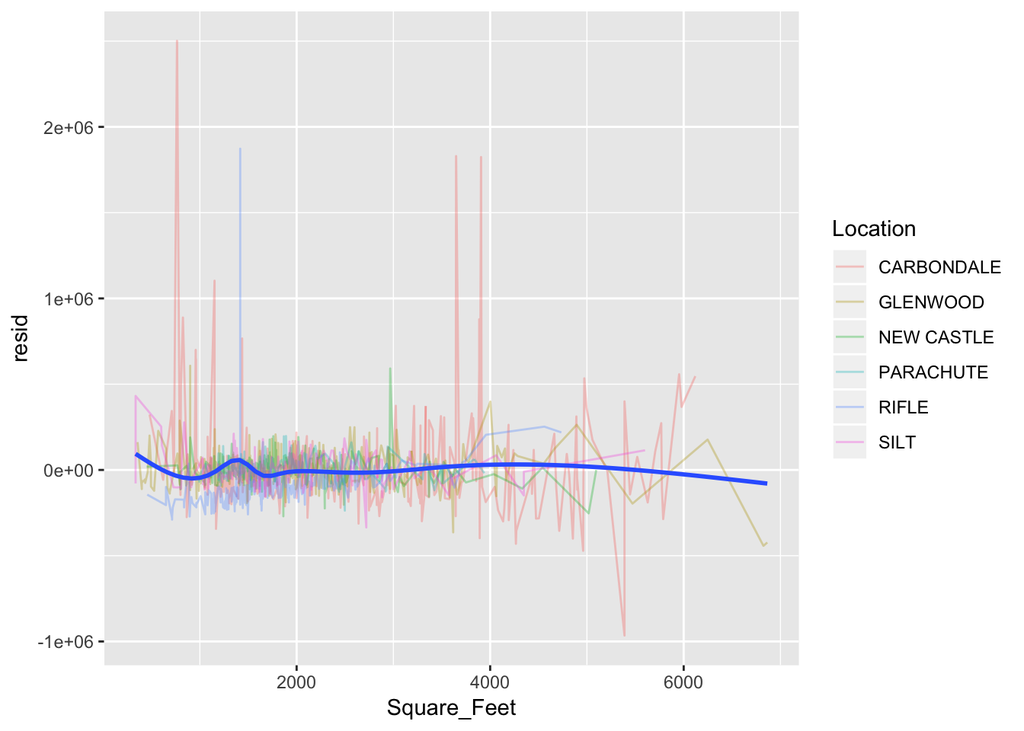

```r
resids %>%
  ggplot(aes(Square_Feet, resid)) +
  geom_line(aes(group = Location, color=Location), alpha = 1 / 3) +
  geom_smooth(se = FALSE)
```

Or, facet by location:

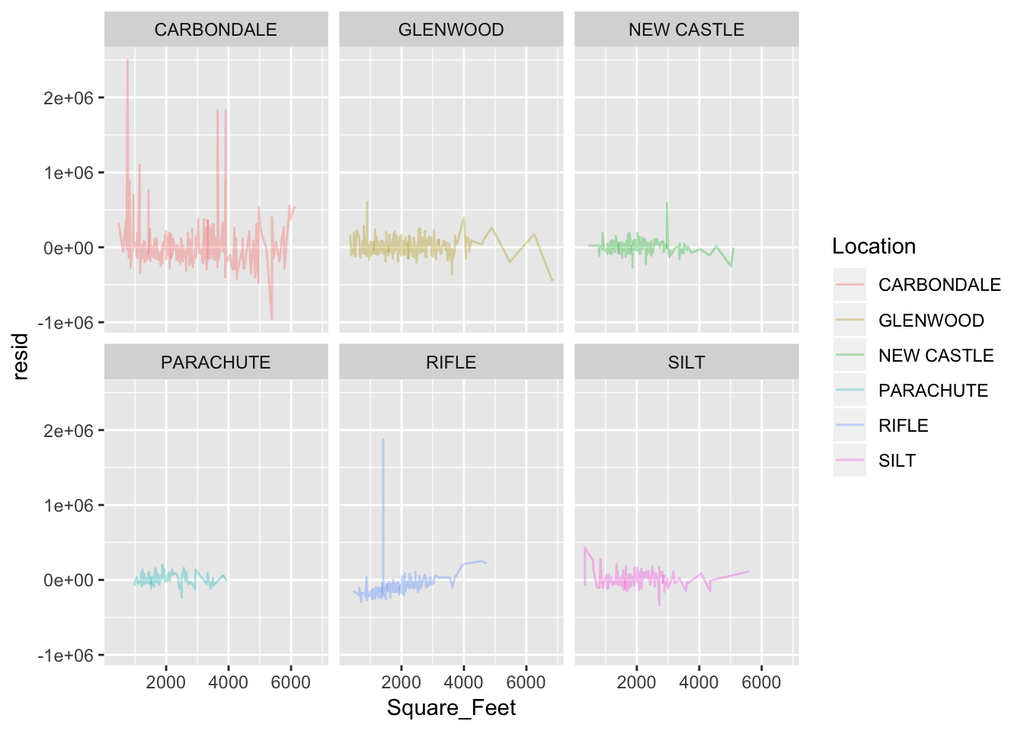

```r
resids %>%
  ggplot(aes(Square_Feet, resid, color = Location)) +
  geom_line(alpha = 1 / 3) +
  facet_wrap(~Location)
```

Based on the figure above, the models for Carbondale and Rifle deserve a closer look.

#Model Quality Wickam: Instead of looking at residuals from the model we could look at some general measurements of model quality using broom::glance(). If we apply it to a model, we get a dataframe with a single row.

```r
broom::glance(glenwood_mod)
```

```
## # A tibble: 1 x 11
##   r.squared adj.r.squared  sigma statistic  p.value    df logLik    AIC
## *     <dbl>         <dbl>  <dbl>     <dbl>    <dbl> <int>  <dbl>  <dbl>
## 1     0.598         0.597 1.12e5      651. 1.06e-88     2 -5737. 11481.
## # ... with 3 more variables: BIC <dbl>, deviance <dbl>, df.residual <int>
```

We can use `mutate()` and `unnest()` to create a dataframe with a row for each location:

```r
by_location %>%
  mutate(glance = map(model, broom::glance)) %>%
  unnest(glance)
```

```
## # A tibble: 6 x 15
##   Location data  model resids r.squared adj.r.squared  sigma statistic
##   <chr>    <lis> <lis> <list>     <dbl>         <dbl>  <dbl>     <dbl>
## 1 CARBOND… <tib… <S3:… <tibb…   4.67e-1       0.466   2.82e5 328.
## 2 GLENWOOD <tib… <S3:… <tibb…   5.98e-1       0.597   1.12e5 651.
## 3 NEW CAS… <tib… <S3:… <tibb…   6.33e-1       0.632   7.25e4 559.
## 4 PARACHU… <tib… <S3:… <tibb…   5.08e-1       0.505   5.99e4 205.
## 5 RIFLE    <tib… <S3:… <tibb…   4.80e-6      -0.00255 4.74e5   0.00188
## 6 SILT     <tib… <S3:… <tibb…   4.71e-1       0.469   8.56e4 197.
## # ... with 7 more variables: p.value <dbl>, df <int>, logLik <dbl>,
## #   AIC <dbl>, BIC <dbl>, deviance <dbl>, df.residual <int>
```

This still includes the list columns. This is the default behavior when `unnest()` works on single-row dataframes. To supress these columns we use .drop = TRUE:

```r
glance <- by_location %>%
  mutate(glance = map(model, broom::glance)) %>%
  unnest(glance, .drop = TRUE)
glance
```

```
## # A tibble: 6 x 12
##   Location r.squared adj.r.squared  sigma statistic  p.value    df logLik
##   <chr>        <dbl>         <dbl>  <dbl>     <dbl>    <dbl> <int>  <dbl>
## 1 CARBOND…   4.67e-1       0.466   2.82e5 328.      4.04e-53     2 -5251.
## 2 GLENWOOD   5.98e-1       0.597   1.12e5 651.      1.06e-88     2 -5737.
## 3 NEW CAS…   6.33e-1       0.632   7.25e4 559.      1.55e-72     2 -4110.
## 4 PARACHU…   5.08e-1       0.505   5.99e4 205.      1.91e-32     2 -2495.
## 5 RIFLE      4.80e-6      -0.00255 4.74e5   0.00188 9.65e- 1     2 -5693.
## 6 SILT       4.71e-1       0.469   8.56e4 197.      2.03e-32     2 -2848.
## # ... with 4 more variables: AIC <dbl>, BIC <dbl>, deviance <dbl>,
## #   df.residual <int>
```

Now we can look for models that don’t fit well:

```r
glance %>%
  arrange(r.squared)
```

```
## # A tibble: 6 x 12
##   Location r.squared adj.r.squared  sigma statistic  p.value    df logLik
##   <chr>        <dbl>         <dbl>  <dbl>     <dbl>    <dbl> <int>  <dbl>
## 1 RIFLE      4.80e-6      -0.00255 4.74e5   0.00188 9.65e- 1     2 -5693.
## 2 CARBOND…   4.67e-1       0.466   2.82e5 328.      4.04e-53     2 -5251.
## 3 SILT       4.71e-1       0.469   8.56e4 197.      2.03e-32     2 -2848.
## 4 PARACHU…   5.08e-1       0.505   5.99e4 205.      1.91e-32     2 -2495.
## 5 GLENWOOD   5.98e-1       0.597   1.12e5 651.      1.06e-88     2 -5737.
## 6 NEW CAS…   6.33e-1       0.632   7.25e4 559.      1.55e-72     2 -4110.
## # ... with 4 more variables: AIC <dbl>, BIC <dbl>, deviance <dbl>,
## #   df.residual <int>
```

As seen earlier, the model is particularly poor for Rifle. Not super useful to plot this small group but…

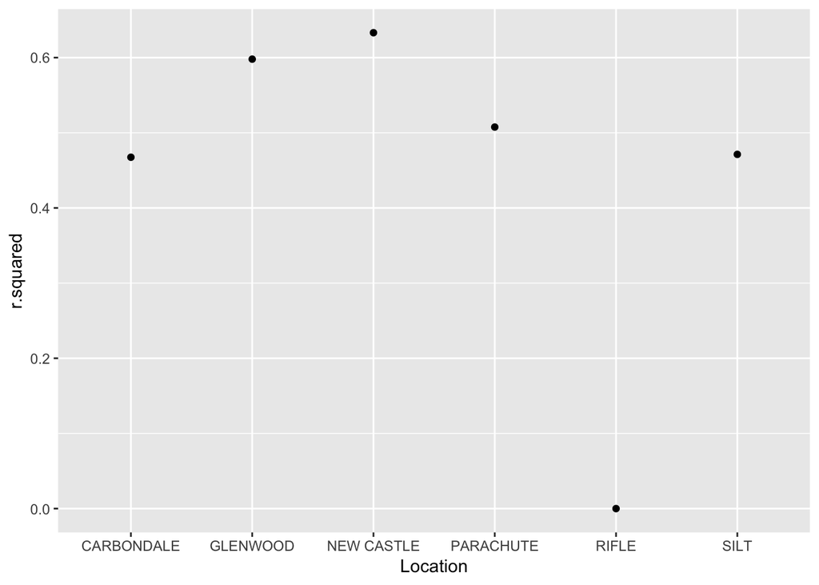

```r
glance %>%
  ggplot(aes(Location, r.squared)) +
  geom_point()
```

#Creating a training and test set to compare model results. To compare model quality I will create a training and test set as per this [method](https://rpubs.com/ID_Tech/S1).

```r
smp_siz <-  floor(0.8*nrow(no_zeros))  # creates a value for dividing the data into train and test. In this case the value is defined as 80% of the number of rows in the dataset
smp_siz  # shows the value of the sample size
```

```
## [1] 1567
```

```r
set.seed(123)   # set seed to ensure you always have same random numbers generated
train_ind <-  sample(seq_len(nrow(no_zeros)),size = smp_siz)  # Randomly identifies therows equal to sample size ( defined in previous instruction) from  all the rows of no_zeros dataset and stores the row number in train_ind
train <- no_zeros[train_ind,] #creates the training dataset with row numbers stored in train_ind
test <- no_zeros[-train_ind,] # creates the test dataset excluding the row numbers mentioned in train_ind
```

I’ll start with some visualizations comparing the two datasets.

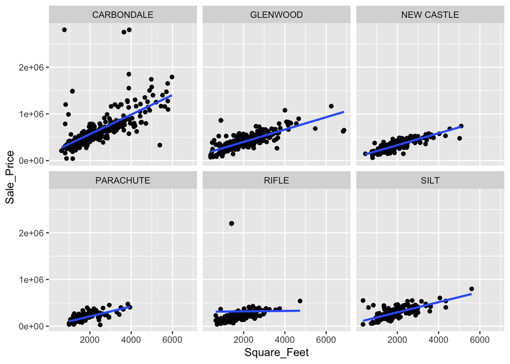

```r
#Training dataset
ggplot(data = train, aes(x = Square_Feet, y = Sale_Price)) +
  geom_point() +
  geom_smooth(method = "lm", se = FALSE) +
  facet_wrap(~ Location)
```

And the test dataset:

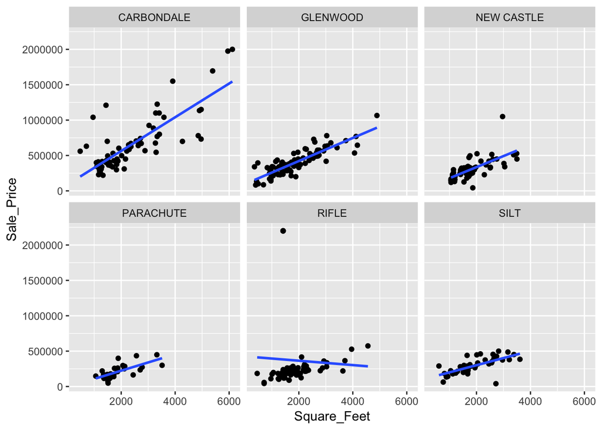

```r
#Test dataset
ggplot(data = test, aes(x = Square_Feet, y = Sale_Price)) +
  geom_point() +
  geom_smooth(method = "lm", se = FALSE) +
  facet_wrap(~ Location)
```

Now to compare the modeling coefficients of each using David Robinson’s 4 step approach.

```r
# David Robinson's Steps 1 thru 4 on training dataset
train_coefficients <- train %>%
  nest(-Location) %>%
  mutate(models = map(data, ~lm(Sale_Price ~ Square_Feet, .))) %>%
  mutate(tidied = map(models, tidy)) %>%
  unnest(tidied)
#Filter for slope values for each location and arrange
train_coefficients %>% filter(term=="Square_Feet") %>% arrange(estimate)
```

```
## # A tibble: 6 x 6
##   Location   term        estimate std.error statistic  p.value
##   <chr>      <chr>          <dbl>     <dbl>     <dbl>    <dbl>
## 1 RIFLE      Square_Feet     4.69     48.4     0.0968 9.23e- 1
## 2 PARACHUTE  Square_Feet   106.        8.15   13.0    7.51e-27
## 3 SILT       Square_Feet   109.        8.72   12.5    4.26e-26
## 4 NEW CASTLE Square_Feet   127.        5.10   24.9    1.10e-70
## 5 GLENWOOD   Square_Feet   132.        6.16   21.5    9.29e-66
## 6 CARBONDALE Square_Feet   209.       14.1    14.9    7.19e-38
```

```r
# David Robinson's Steps 1 thru 4 on test dataset
test_coefficients <- test %>%
  nest(-Location) %>%
  mutate(models = map(data, ~lm(Sale_Price ~ Square_Feet, .))) %>%
  mutate(tidied = map(models, tidy)) %>%
  unnest(tidied)
#Filter for slope values for each location and arrange
test_coefficients %>% filter(term=="Square_Feet") %>% arrange(estimate)
```

```
## # A tibble: 6 x 6
##   Location   term        estimate std.error statistic  p.value
##   <chr>      <chr>          <dbl>     <dbl>     <dbl>    <dbl>
## 1 RIFLE      Square_Feet    -30.8      87.1    -0.354 7.24e- 1
## 2 SILT       Square_Feet    101.       16.4     6.17  1.88e- 7
## 3 PARACHUTE  Square_Feet    116.       20.6     5.65  2.42e- 6
## 4 NEW CASTLE Square_Feet    156.       20.6     7.59  1.71e-10
## 5 GLENWOOD   Square_Feet    163.       10.4    15.7   2.85e-27
## 6 CARBONDALE Square_Feet    238.       20.6    11.6   2.77e-18
```

Overall the results look reasonably close between the training set and the test set. What about using the approach above with `broom::glance()` instead of `broom::tidy()`? The approach below combines David Robinson’s 4-step approach with the `broom::glance()` example described by Wickam.

```r
train_glance <- train %>%
  nest(-Location) %>%
  mutate(models = map(data, ~lm(Sale_Price ~ Square_Feet, .))) %>%
  mutate(glance = map(models, broom::glance)) %>%
  unnest(glance, .drop = TRUE)
train_glance%>% arrange(r.squared)
```

```
## # A tibble: 6 x 12
##   Location r.squared adj.r.squared  sigma statistic  p.value    df logLik
##   <chr>        <dbl>         <dbl>  <dbl>     <dbl>    <dbl> <int>  <dbl>
## 1 RIFLE    0.0000299      -0.00316 4.57e5   0.00937 9.23e- 1     2 -4551.
## 2 CARBOND… 0.427           0.425   2.94e5 222.      7.19e-38     2 -4202.
## 3 SILT     0.473           0.470   8.69e4 157.      4.26e-26     2 -2263.
## 4 PARACHU… 0.507           0.504   5.84e4 168.      7.51e-27     2 -2044.
## 5 GLENWOOD 0.570           0.569   1.16e5 461.      9.29e-66     2 -4576.
## 6 NEW CAS… 0.707           0.706   6.07e4 622.      1.10e-70     2 -3232.
## # ... with 4 more variables: AIC <dbl>, BIC <dbl>, deviance <dbl>,
## #   df.residual <int>
```

In the results above you can see that everything is already arranged by r.squared, lowest to highest. The model fits very poorly for Rifle.

```r
test_glance <- test %>%
  nest(-Location) %>%
  mutate(models = map(data, ~lm(Sale_Price ~ Square_Feet, .))) %>%
  mutate(glance = map(models, broom::glance)) %>%
  unnest(glance, .drop = TRUE)
test_glance %>% arrange(r.squared)
```

```
## # A tibble: 6 x 12
##   Location r.squared adj.r.squared  sigma statistic  p.value    df logLik
##   <chr>        <dbl>         <dbl>  <dbl>     <dbl>    <dbl> <int>  <dbl>
## 1 RIFLE      0.00165       -0.0115 5.42e5     0.125 7.24e- 1     2 -1139.
## 2 SILT       0.464          0.452  8.16e4    38.1   1.88e- 7     2  -584.
## 3 NEW CAS…   0.474          0.465  1.07e5    57.6   1.71e-10     2  -857.
## 4 PARACHU…   0.485          0.469  6.70e4    32.0   2.42e- 6     2  -450.
## 5 CARBOND…   0.644          0.640  2.28e5   134.    2.77e-18     2 -1044.
## 6 GLENWOOD   0.737          0.734  9.01e4   247.    2.85e-27     2 -1154.
## # ... with 4 more variables: AIC <dbl>, BIC <dbl>, deviance <dbl>,
## #   df.residual <int>
```

What about augment? Can we apply the 4-step process to this too?

```r
train_augment <- train %>%
  nest(-Location) %>%
  mutate(models = map(data, ~lm(Sale_Price ~ Square_Feet, .))) %>%
  mutate(augment = map(models, broom::augment)) %>%
  unnest(augment)
train_augment
```

```
## # A tibble: 1,567 x 10
##    Location Sale_Price Square_Feet .fitted .se.fit  .resid    .hat .sigma
##    <chr>         <int>       <dbl>   <dbl>   <dbl>   <dbl>   <dbl>  <dbl>
##  1 RIFLE        137000        1920 317212.  28722. -1.80e5 0.00395 4.58e5
##  2 RIFLE        228000        1354 314557.  29650. -8.66e4 0.00421 4.58e5
##  3 RIFLE        285000        2405 319487.  44442. -3.45e4 0.00946 4.58e5
##  4 RIFLE        305000        2624 320515.  53445. -1.55e4 0.0137  4.58e5
##  5 RIFLE        225000        2808 321378.  61407. -9.64e4 0.0181  4.58e5
##  6 RIFLE         86000        1360 314585.  29507. -2.29e5 0.00417 4.58e5
##  7 RIFLE        259000        2360 319276.  42684. -6.03e4 0.00872 4.58e5
##  8 RIFLE        124900        1632 315861.  25779. -1.91e5 0.00318 4.58e5
##  9 RIFLE        377000        2568 320252.  51084.  5.67e4 0.0125  4.58e5
## 10 RIFLE        220000        1272 314173.  31807. -9.42e4 0.00484 4.58e5
## # ... with 1,557 more rows, and 2 more variables: .cooksd <dbl>,
## #   .std.resid <dbl>
```

What about augment? Can we apply the 4-step process to this too?

```r
test_augment <- test %>%
  nest(-Location) %>%
  mutate(models = map(data, ~lm(Sale_Price ~ Square_Feet, .))) %>%
  mutate(augment = map(models, broom::augment)) %>%
  unnest(augment)
test_augment
```

```
## # A tibble: 392 x 10
##    Location Sale_Price Square_Feet .fitted .se.fit  .resid   .hat .sigma
##    <chr>         <int>       <dbl>   <dbl>   <dbl>   <dbl>  <dbl>  <dbl>
##  1 CARBOND…     345000        1099 349221.  35633. -4.22e3 0.0245 2.29e5
##  2 CARBOND…     229000        1164 364706.  34737. -1.36e5 0.0233 2.29e5
##  3 CARBOND…     307000        1188 370424.  34414. -6.34e4 0.0229 2.29e5
##  4 CARBOND…     280000        1200 373282.  34254. -9.33e4 0.0226 2.29e5
##  5 CARBOND…     355000        1200 373282.  34254. -1.83e4 0.0226 2.29e5
##  6 CARBOND…     379000        1210 375665.  34121.  3.34e3 0.0225 2.29e5
##  7 CARBOND…     385000        1210 375665.  34121.  9.34e3 0.0225 2.29e5
##  8 CARBOND…     280000        1215 376856.  34055. -9.69e4 0.0224 2.29e5
##  9 CARBOND…     239000        1215 376856.  34055. -1.38e5 0.0224 2.29e5
## 10 CARBOND…     265000        1224 379000.  33936. -1.14e5 0.0222 2.29e5
## # ... with 382 more rows, and 2 more variables: .cooksd <dbl>,
## #   .std.resid <dbl>
```

#Using a Robust Linear Model (MASS package) From Wickham ggplor2 book Chapter 2.6.1. The MASS package offers a robust fitting algorithm so that outliers don’t affect the fit as much.

NOTE: You can’t load MASS package before any dplyr::select() calls appear in the code because the dplyr::select() is masked by the MASS package and does not work on subsequent code.

```r
#Training dataset modeled with robust linear model
library(MASS)
```

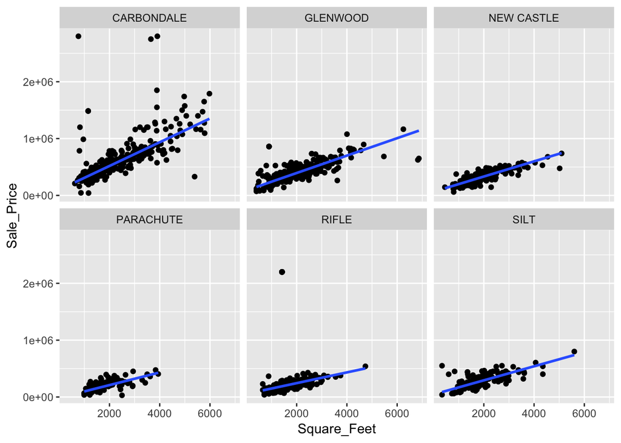

```r
ggplot(data = train, aes(x = Square_Feet, y = Sale_Price)) +
  geom_point() +
  geom_smooth(method = "rlm", se = FALSE) +
  facet_wrap(~ Location)
```

And looking at the test dataset:

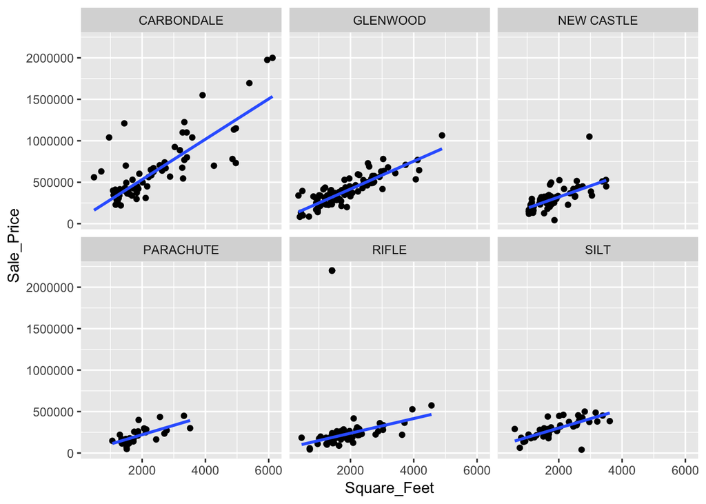

```r
#Test dataset
ggplot(data = test, aes(x = Square_Feet, y = Sale_Price)) +
  geom_point() +
  geom_smooth(method = "rlm", se = FALSE) + #rlm from MASS package
  facet_wrap(~ Location)
```

Write the no_zeros file to csv to open in different file to remove outliers from Rifle (it appears multiple condos sold at one time for 2.2M total, but were recorded as 2.2M each).

```r
write_csv(no_zeros, "garfield_no_zeros.csv")
```